# ANCOVA in Vocabulario Não Ensinado (Vocabulario Não Ensinado)

Geiser C. Challco geiser@alumni.usp.br

- Descriptive Statistics of Initial Data
- ANCOVA and Pairwise for one factor: **grupo**
  - Without remove non-normal data
  - Computing ANCOVA and PairWise After removing non-normal data (OK)
    - Plots for ancova
    - Checking linearity assumption
    - Checking normality and homogeneity
- ANCOVA and Pairwise for two factors **grupo:Sexo**
  - Without remove non-normal data
  - Computing ANCOVA and PairWise After removing non-normal data (OK)
    - Plots for ancova
    - Checking linearity assumption
    - Checking normality and homogeneity
- ANCOVA and Pairwise for two factors **grupo:Zona**
  - Without remove non-normal data
  - Computing ANCOVA and PairWise After removing non-normal data (OK)
    - Plots for ancova
    - Checking linearity assumption
    - Checking normality and homogeneity
- ANCOVA and Pairwise for two factors **grupo:Cor.Raca**
  - Without remove non-normal data
  - Computing ANCOVA and PairWise After removing non-normal data (OK)
    - Plots for ancova
    - Checking linearity assumption
    - Checking normality and homogeneity
- ANCOVA and Pairwise for two factors **grupo:Serie**
  - Without remove non-normal data
  - Computing ANCOVA and PairWise After removing non-normal data (OK)
    - Plots for ancova
    - Checking linearity assumption
    - Checking normality and homogeneity
- Summary of Results
  - Descriptive Statistics
  - ANCOVA Table Comparison
  - PairWise Table Comparison
  - EMMS Table Comparison

**NOTE**:

- Teste ANCOVA para determinar se houve diferenças significativas no Vocabulario Não Ensinado (medido usando pre- e pos-testes).
- ANCOVA test to determine whether there were significant differences in Vocabulario Não Ensinado (measured using pre- and post-tests).

# Descriptive Statistics of Initial Data

```r
df <- get.descriptives(dat, c(dv.pre, dv.pos), c("grupo"),
                       include.global = T, symmetry.test = T, normality.test = F)
df <- plyr::rbind.fill(
  df, do.call(plyr::rbind.fill, lapply(lfatores2, FUN = function(f) {
    if (nrow(dat) > 0 && sum(!is.na(unique(dat[[f]]))) > 1)
      get.descriptives(dat, c(dv.pre,dv.pos), c("grupo", f),
                       symmetry.test = T, normality.test = F)
    }))
)
(df <- df[,c(fatores1[fatores1 %in% colnames(df)],"variable",
             colnames(df)[!colnames(df) %in% c(fatores1,"variable")])])
```

```
##           grupo Sexo   Zona Cor.Raca Serie            variable   n   mean median min max    sd    se
## 1      Controle <NA>   <NA>     <NA>  <NA> vocab.non.teach.pre  89 31.854   31.0  30  39 1.868 0.198
## 2  Experimental <NA>   <NA>     <NA>  <NA> vocab.non.teach.pre 137 31.912   31.0  30  37 1.743 0.149
## 3          <NA> <NA>   <NA>     <NA>  <NA> vocab.non.teach.pre 226 31.889   31.0  30  39 1.789 0.119
## 4      Controle <NA>   <NA>     <NA>  <NA> vocab.non.teach.pos  89 29.753   31.0   8  36 5.593 0.593
## 5  Experimental <NA>   <NA>     <NA>  <NA> vocab.non.teach.pos 137 30.343   31.0  12  37 4.281 0.366
## 6          <NA> <NA>   <NA>     <NA>  <NA> vocab.non.teach.pos 226 30.111   31.0   8  37 4.837 0.322
## 7      Controle    F   <NA>     <NA>  <NA> vocab.non.teach.pre  48 31.771   31.0  30  39 2.024 0.292
## 8      Controle    M   <NA>     <NA>  <NA> vocab.non.teach.pre  41 31.951   32.0  30  35 1.687 0.264
## 9  Experimental    F   <NA>     <NA>  <NA> vocab.non.teach.pre  77 31.935   32.0  30  37 1.649 0.188
## 10 Experimental    M   <NA>     <NA>  <NA> vocab.non.teach.pre  60 31.883   31.0  30  37 1.869 0.241
## 11     Controle    F   <NA>     <NA>  <NA> vocab.non.teach.pos  48 30.188   31.0   8  35 4.823 0.696
## 12     Controle    M   <NA>     <NA>  <NA> vocab.non.teach.pos  41 29.244   31.0   9  36 6.402 1.000
## 13 Experimental    F   <NA>     <NA>  <NA> vocab.non.teach.pos  77 30.714   31.0  12  37 4.036 0.460
## 14 Experimental    M   <NA>     <NA>  <NA> vocab.non.teach.pos  60 29.867   30.0  13  37 4.568 0.590
```

[output cut: 98 more lines]

| grupo | Sexo | Zona | Cor.Raca | Serie | variable | n | mean | median | min | max | sd | se | ci | iqr | symmetry | skewness | kurtosis |
| --- | --- | --- | --- | --- | --- | --- | --- | --- | --- | --- | --- | --- | --- | --- | --- | --- | --- |
| Controle |  |  |  |  | vocab.non.teach.pre | 89 | 31.854 | 31.0 | 30 | 39 | 1.868 | 0.198 | 0.394 | 3.00 | NO | 1.172 | 1.302 |
| Experimental |  |  |  |  | vocab.non.teach.pre | 137 | 31.912 | 31.0 | 30 | 37 | 1.743 | 0.149 | 0.294 | 3.00 | NO | 0.787 | -0.106 |
|  |  |  |  |  | vocab.non.teach.pre | 226 | 31.889 | 31.0 | 30 | 39 | 1.789 | 0.119 | 0.235 | 3.00 | NO | 0.963 | 0.574 |
| Controle |  |  |  |  | vocab.non.teach.pos | 89 | 29.753 | 31.0 | 8 | 36 | 5.593 | 0.593 | 1.178 | 5.00 | NO | -2.110 | 4.821 |
| Experimental |  |  |  |  | vocab.non.teach.pos | 137 | 30.343 | 31.0 | 12 | 37 | 4.281 | 0.366 | 0.723 | 4.00 | NO | -1.876 | 5.049 |
|  |  |  |  |  | vocab.non.teach.pos | 226 | 30.111 | 31.0 | 8 | 37 | 4.837 | 0.322 | 0.634 | 4.00 | NO | -2.121 | 5.752 |
| Controle | F |  |  |  | vocab.non.teach.pre | 48 | 31.771 | 31.0 | 30 | 39 | 2.024 | 0.292 | 0.588 | 3.00 | NO | 1.573 | 2.262 |
| Controle | M |  |  |  | vocab.non.teach.pre | 41 | 31.951 | 32.0 | 30 | 35 | 1.687 | 0.264 | 0.533 | 3.00 | YES | 0.349 | -1.214 |
| Experimental | F |  |  |  | vocab.non.teach.pre | 77 | 31.935 | 32.0 | 30 | 37 | 1.649 | 0.188 | 0.374 | 2.00 | NO | 0.658 | -0.055 |
| Experimental | M |  |  |  | vocab.non.teach.pre | 60 | 31.883 | 31.0 | 30 | 37 | 1.869 | 0.241 | 0.483 | 3.00 | NO | 0.886 | -0.276 |
| Controle | F |  |  |  | vocab.non.teach.pos | 48 | 30.188 | 31.0 | 8 | 35 | 4.823 | 0.696 | 1.400 | 4.25 | NO | -2.363 | 7.511 |
| Controle | M |  |  |  | vocab.non.teach.pos | 41 | 29.244 | 31.0 | 9 | 36 | 6.402 | 1.000 | 2.021 | 5.00 | NO | -1.770 | 2.627 |
| Experimental | F |  |  |  | vocab.non.teach.pos | 77 | 30.714 | 31.0 | 12 | 37 | 4.036 | 0.460 | 0.916 | 4.00 | NO | -1.949 | 5.818 |
| Experimental | M |  |  |  | vocab.non.teach.pos | 60 | 29.867 | 30.0 | 13 | 37 | 4.568 | 0.590 | 1.180 | 5.00 | NO | -1.736 | 4.024 |
| Controle |  | Rural |  |  | vocab.non.teach.pre | 28 | 31.821 | 31.0 | 30 | 39 | 2.127 | 0.402 | 0.825 | 3.00 | NO | 1.584 | 2.463 |
| Controle |  | Urbana |  |  | vocab.non.teach.pre | 26 | 31.500 | 31.0 | 30 | 35 | 1.606 | 0.315 | 0.649 | 2.75 | NO | 0.919 | -0.489 |
| Controle |  |  |  |  | vocab.non.teach.pre | 35 | 32.143 | 32.0 | 30 | 37 | 1.833 | 0.310 | 0.630 | 2.00 | NO | 0.630 | -0.392 |
| Experimental |  | Rural |  |  | vocab.non.teach.pre | 46 | 31.935 | 32.0 | 30 | 36 | 1.482 | 0.218 | 0.440 | 2.00 | YES | 0.430 | -0.325 |
| Experimental |  | Urbana |  |  | vocab.non.teach.pre | 42 | 31.786 | 31.0 | 30 | 37 | 1.855 | 0.286 | 0.578 | 3.00 | NO | 0.933 | -0.188 |
| Experimental |  |  |  |  | vocab.non.teach.pre | 49 | 32.000 | 31.0 | 30 | 37 | 1.893 | 0.270 | 0.544 | 3.00 | NO | 0.776 | -0.343 |
| Controle |  | Rural |  |  | vocab.non.teach.pos | 28 | 29.857 | 32.0 | 9 | 36 | 5.816 | 1.099 | 2.255 | 4.75 | NO | -1.869 | 3.777 |
| Controle |  | Urbana |  |  | vocab.non.teach.pos | 26 | 30.731 | 31.0 | 20 | 35 | 3.157 | 0.619 | 1.275 | 2.75 | NO | -1.391 | 2.847 |
| Controle |  |  |  |  | vocab.non.teach.pos | 35 | 28.943 | 32.0 | 8 | 35 | 6.734 | 1.138 | 2.313 | 6.00 | NO | -1.749 | 2.409 |
| Experimental |  | Rural |  |  | vocab.non.teach.pos | 46 | 29.326 | 31.0 | 12 | 37 | 5.457 | 0.805 | 1.621 | 4.00 | NO | -1.832 | 3.086 |
| Experimental |  | Urbana |  |  | vocab.non.teach.pos | 42 | 30.738 | 31.0 | 17 | 36 | 3.663 | 0.565 | 1.141 | 3.75 | NO | -1.316 | 2.871 |
| Experimental |  |  |  |  | vocab.non.teach.pos | 49 | 30.959 | 31.0 | 21 | 37 | 3.323 | 0.475 | 0.954 | 5.00 | NO | -0.706 | 0.256 |
| Controle |  |  | Branca |  | vocab.non.teach.pre | 7 | 31.571 | 31.0 | 30 | 34 | 1.512 | 0.571 | 1.398 | 2.00 | YES | 0.380 | -1.595 |
| Controle |  |  | Indígena |  | vocab.non.teach.pre | 1 | 34.000 | 34.0 | 34 | 34 |  |  |  | 0.00 | few data | 0.000 | 0.000 |
| Controle |  |  | Parda |  | vocab.non.teach.pre | 24 | 31.542 | 31.0 | 30 | 39 | 1.956 | 0.399 | 0.826 | 2.00 | NO | 2.297 | 6.074 |
| Controle |  |  |  |  | vocab.non.teach.pre | 57 | 31.982 | 31.0 | 30 | 37 | 1.876 | 0.248 | 0.498 | 3.00 | NO | 0.711 | -0.568 |
| Experimental |  |  | Branca |  | vocab.non.teach.pre | 17 | 31.765 | 32.0 | 30 | 34 | 1.522 | 0.369 | 0.782 | 3.00 | YES | -0.027 | -1.683 |
| Experimental |  |  | Indígena |  | vocab.non.teach.pre | 1 | 30.000 | 30.0 | 30 | 30 |  |  |  | 0.00 | few data | 0.000 | 0.000 |
| Experimental |  |  | Parda |  | vocab.non.teach.pre | 31 | 31.806 | 31.0 | 30 | 35 | 1.515 | 0.272 | 0.556 | 1.50 | NO | 0.818 | -0.410 |
| Experimental |  |  |  |  | vocab.non.teach.pre | 88 | 32.000 | 31.5 | 30 | 37 | 1.863 | 0.199 | 0.395 | 3.00 | NO | 0.791 | -0.214 |
| Controle |  |  | Branca |  | vocab.non.teach.pos | 7 | 32.571 | 33.0 | 30 | 36 | 2.573 | 0.972 | 2.379 | 4.50 | YES | 0.055 | -1.995 |
| Controle |  |  | Indígena |  | vocab.non.teach.pos | 1 | 35.000 | 35.0 | 35 | 35 |  |  |  | 0.00 | few data | 0.000 | 0.000 |
| Controle |  |  | Parda |  | vocab.non.teach.pos | 24 | 28.458 | 31.0 | 8 | 34 | 6.997 | 1.428 | 2.954 | 7.50 | NO | -1.516 | 1.568 |
| Controle |  |  |  |  | vocab.non.teach.pos | 57 | 29.860 | 31.0 | 9 | 35 | 5.111 | 0.677 | 1.356 | 5.00 | NO | -2.244 | 5.898 |
| Experimental |  |  | Branca |  | vocab.non.teach.pos | 17 | 31.294 | 31.0 | 26 | 37 | 2.889 | 0.701 | 1.485 | 3.00 | YES | 0.134 | -0.729 |
| Experimental |  |  | Indígena |  | vocab.non.teach.pos | 1 | 29.000 | 29.0 | 29 | 29 |  |  |  | 0.00 | few data | 0.000 | 0.000 |
| Experimental |  |  | Parda |  | vocab.non.teach.pos | 31 | 30.484 | 32.0 | 13 | 37 | 4.456 | 0.800 | 1.635 | 5.00 | NO | -1.875 | 5.144 |
| Experimental |  |  |  |  | vocab.non.teach.pos | 88 | 30.125 | 31.0 | 12 | 36 | 4.474 | 0.477 | 0.948 | 4.00 | NO | -1.851 | 4.285 |
| Controle |  |  |  | 6 ano | vocab.non.teach.pre | 12 | 31.000 | 31.0 | 30 | 34 | 1.279 | 0.369 | 0.813 | 1.00 | NO | 1.194 | 0.174 |
| Controle |  |  |  | 7 ano | vocab.non.teach.pre | 21 | 31.333 | 31.0 | 30 | 35 | 1.528 | 0.333 | 0.695 | 1.00 | NO | 1.063 | -0.205 |
| Controle |  |  |  | 8 ano | vocab.non.teach.pre | 15 | 32.200 | 31.0 | 30 | 39 | 2.455 | 0.634 | 1.360 | 2.50 | NO | 1.325 | 1.243 |
| Controle |  |  |  | 9 ano | vocab.non.teach.pre | 41 | 32.244 | 32.0 | 30 | 37 | 1.841 | 0.288 | 0.581 | 2.00 | NO | 0.611 | -0.458 |
| Experimental |  |  |  | 6 ano | vocab.non.teach.pre | 12 | 31.250 | 31.0 | 30 | 34 | 1.422 | 0.411 | 0.904 | 2.25 | NO | 0.641 | -1.198 |
| Experimental |  |  |  | 7 ano | vocab.non.teach.pre | 27 | 31.593 | 32.0 | 30 | 35 | 1.309 | 0.252 | 0.518 | 2.00 | YES | 0.450 | -0.419 |
| Experimental |  |  |  | 8 ano | vocab.non.teach.pre | 45 | 31.889 | 31.0 | 30 | 36 | 1.748 | 0.261 | 0.525 | 2.00 | NO | 0.765 | -0.451 |
| Experimental |  |  |  | 9 ano | vocab.non.teach.pre | 53 | 32.245 | 32.0 | 30 | 37 | 1.950 | 0.268 | 0.538 | 3.00 | NO | 0.607 | -0.571 |
| Controle |  |  |  | 6 ano | vocab.non.teach.pos | 12 | 29.833 | 30.5 | 26 | 32 | 2.125 | 0.613 | 1.350 | 2.75 | NO | -0.583 | -1.296 |
| Controle |  |  |  | 7 ano | vocab.non.teach.pos | 21 | 29.381 | 31.0 | 9 | 36 | 6.054 | 1.321 | 2.756 | 3.00 | NO | -1.977 | 3.879 |
| Controle |  |  |  | 8 ano | vocab.non.teach.pos | 15 | 27.733 | 33.0 | 8 | 35 | 9.573 | 2.472 | 5.301 | 9.00 | NO | -1.071 | -0.573 |
| Controle |  |  |  | 9 ano | vocab.non.teach.pos | 41 | 30.659 | 32.0 | 20 | 35 | 3.838 | 0.599 | 1.211 | 4.00 | NO | -1.039 | 0.028 |
| Experimental |  |  |  | 6 ano | vocab.non.teach.pos | 12 | 30.000 | 32.0 | 17 | 34 | 4.729 | 1.365 | 3.005 | 2.50 | NO | -1.711 | 1.944 |
| Experimental |  |  |  | 7 ano | vocab.non.teach.pos | 27 | 28.556 | 29.0 | 14 | 35 | 4.807 | 0.925 | 1.901 | 4.00 | NO | -1.409 | 1.914 |
| Experimental |  |  |  | 8 ano | vocab.non.teach.pos | 45 | 30.244 | 31.0 | 12 | 35 | 4.711 | 0.702 | 1.415 | 4.00 | NO | -2.340 | 6.301 |
| Experimental |  |  |  | 9 ano | vocab.non.teach.pos | 53 | 31.415 | 31.0 | 24 | 37 | 3.165 | 0.435 | 0.872 | 4.00 | YES | -0.350 | -0.505 |

# ANCOVA and Pairwise for one factor: **grupo**

## Without remove non-normal data

```r
pdat = remove_group_data(dat[!is.na(dat[["grupo"]]),], "vocab.non.teach.pos", "grupo")

pdat.long <- rbind(pdat[,c("id","grupo")], pdat[,c("id","grupo")])
pdat.long[["time"]] <- c(rep("pre", nrow(pdat)), rep("pos", nrow(pdat)))
pdat.long[["time"]] <- factor(pdat.long[["time"]], c("pre","pos"))
pdat.long[["vocab.non.teach"]] <- c(pdat[["vocab.non.teach.pre"]], pdat[["vocab.non.teach.pos"]])

aov = anova_test(pdat, vocab.non.teach.pos ~ vocab.non.teach.pre + grupo)
laov[["grupo"]] <- get_anova_table(aov)
```

```r
pwc <- emmeans_test(pdat, vocab.non.teach.pos ~ grupo, covariate = vocab.non.teach.pre,
                    p.adjust.method = "bonferroni")
```

```r
pwc.long <- emmeans_test(dplyr::group_by_at(pdat.long, "grupo"),
                          vocab.non.teach ~ time,
                          p.adjust.method = "bonferroni")
lpwc[["grupo"]] <- plyr::rbind.fill(pwc, pwc.long)
```

```r
ds <- get.descriptives(pdat, "vocab.non.teach.pos", "grupo", covar = "vocab.non.teach.pre")
ds <- merge(ds[ds$variable != "vocab.non.teach.pre",],
            ds[ds$variable == "vocab.non.teach.pre", !colnames(ds) %in% c("variable")],
            by = "grupo", all.x = T, suffixes = c("", ".vocab.non.teach.pre"))
ds <- merge(get_emmeans(pwc), ds, by = "grupo", suffixes = c(".emms", ""))
ds <- ds[,c("grupo","n","mean.vocab.non.teach.pre","se.vocab.non.teach.pre","mean","se","emmean","se.emms")]

colnames(ds) <- c("grupo", "N", paste0(c("M","SE")," (pre)"),
                  paste0(c("M","SE"), " (unadj)"), paste0(c("M", "SE"), " (adj)"))

lemms[["grupo"]] <- ds
```

## Computing ANCOVA and PairWise After removing non-normal data (OK)

```r
wdat = pdat

res = residuals(lm(vocab.non.teach.pos ~ vocab.non.teach.pre + grupo, data = wdat))
non.normal = getNonNormal(res, wdat$id, plimit = 0.05)

wdat = wdat[!wdat$id %in% non.normal,]

wdat.long <- rbind(wdat[,c("id","grupo")], wdat[,c("id","grupo")])
wdat.long[["time"]] <- c(rep("pre", nrow(wdat)), rep("pos", nrow(wdat)))
wdat.long[["time"]] <- factor(wdat.long[["time"]], c("pre","pos"))
wdat.long[["vocab.non.teach"]] <- c(wdat[["vocab.non.teach.pre"]], wdat[["vocab.non.teach.pos"]])

ldat[["grupo"]] = wdat

(non.normal)
```

```
##   [1] "P1003" "P983"  "P2232" "P996"  "P2207" "P1966" "P3654" "P916"  "P976"  "P1794" "P1012" "P1865"
##  [13] "P3280" "P2069" "P1116" "P3228" "P3574" "P2113" "P932"  "P2066" "P526"  "P2322" "P3720" "P3157"
##  [25] "P2432" "P2447" "P2306" "P1060" "P3225" "P999"  "P3222" "P1985" "P3258" "P2146" "P2079" "P596"
##  [37] "P633"  "P3284" "P2123" "P1851" "P2379" "P3151" "P1100" "P986"  "P3723" "P3138" "P3646" "P1138"
##  [49] "P3242" "P1085" "P1001" "P2428" "P2065" "P2459" "P2300" "P3676" "P2150" "P2360" "P3610" "P2292"
##  [61] "P3719" "P3245" "P1617" "P2387" "P1876" "P1761" "P3657" "P2869" "P588"  "P2191" "P1650" "P2008"
##  [73] "P2299" "P2225" "P2412" "P2475" "P2367" "P2139" "P1888" "P1749" "P828"  "P3283" "P1853" "P2423"
##  [85] "P1648" "P2431" "P2361" "P2370" "P3264" "P2064" "P3129" "P1879" "P2298" "P2984" "P1679" "P2118"
##  [97] "P3192" "P3144" "P605"  "P2441" "P2323" "P1900" "P2372" "P3589" "P1153" "P3202" "P1133" "P3226"
## [109] "P1913" "P1061" "P3171" "P2196" "P2871" "P1825" "P3147" "P2308" "P1846" "P3301" "P3643" "P928"
## [121] "P552"  "P1652" "P1674" "P1908" "P2457" "P2343" "P2845" "P2476" "P2295" "P3708" "P2393" "P1665"
## [133] "P846"  "P3576" "P1689" "P980"  "P2990" "P3079" "P3639" "P2436" "P3688" "P600"  "P2354" "P2452"
## [145] "P1848" "P2188" "P2181" "P1800" "P3148" "P2477" "P2910" "P2480" "P2381" "P3693" "P2362" "P3645"
## [157] "P3150" "P2467" "P2131" "P2141" "P2948" "P2200" "P597"  "P3587" "P2319" "P2394" "P832"  "P2357"
## [169] "P3652" "P2296"
```

```r
aov = anova_test(wdat, vocab.non.teach.pos ~ vocab.non.teach.pre + grupo)
laov[["grupo"]] <- merge(get_anova_table(aov), laov[["grupo"]], by="Effect", suffixes = c("","'"))

(df = get_anova_table(aov))
```

```
## ANOVA Table (type II tests)
##
##                Effect DFn DFd      F        p p<.05   ges
## 1 vocab.non.teach.pre   1  53 29.682 1.35e-06     * 0.359
## 2               grupo   1  53  8.087 6.00e-03     * 0.132
```

| Effect | DFn | DFd | F | p | p<.05 | ges |
| --- | --- | --- | --- | --- | --- | --- |
| vocab.non.teach.pre | 1 | 53 | 29.682 | 0.000 | * | 0.359 |
| grupo | 1 | 53 | 8.087 | 0.006 | * | 0.132 |

[output not shown]

```r
pwc.long <- emmeans_test(dplyr::group_by_at(wdat.long, "grupo"),
                         vocab.non.teach ~ time,
                         p.adjust.method = "bonferroni")
lpwc[["grupo"]] <- merge(plyr::rbind.fill(pwc, pwc.long), lpwc[["grupo"]], by=c("grupo","term",".y.","group1","group2"), suffixes = c("","'"))
```

| grupo | term | .y. | group1 | group2 | df | statistic | p | p.adj | p.adj.signif |
| --- | --- | --- | --- | --- | --- | --- | --- | --- | --- |
| Controle | time | vocab.non.teach | pre | pos | 108 | 8.313 | 0 | 0 | **** |
| Experimental | time | vocab.non.teach | pre | pos | 108 | 10.252 | 0 | 0 | **** |

```r
ds <- get.descriptives(wdat, "vocab.non.teach.pos", "grupo", covar = "vocab.non.teach.pre")
ds <- merge(ds[ds$variable != "vocab.non.teach.pre",],
            ds[ds$variable == "vocab.non.teach.pre", !colnames(ds) %in% c("variable")],
            by = "grupo", all.x = T, suffixes = c("", ".vocab.non.teach.pre"))
ds <- merge(get_emmeans(pwc), ds, by = "grupo", suffixes = c(".emms", ""))
ds <- ds[,c("grupo","n","mean.vocab.non.teach.pre","se.vocab.non.teach.pre","mean","se","emmean","se.emms")]

colnames(ds) <- c("grupo", "N", paste0(c("M","SE")," (pre)"),
                  paste0(c("M","SE"), " (unadj)"), paste0(c("M", "SE"), " (adj)"))

lemms[["grupo"]] <- merge(ds, lemms[["grupo"]], by=c("grupo"), suffixes = c("","'"))
```

| grupo | N | M (pre) | SE (pre) | M (unadj) | SE (unadj) | M (adj) | SE (adj) |
| --- | --- | --- | --- | --- | --- | --- | --- |
| Controle | 16 | 31.50 | 0.483 | 26.50 | 0.465 | 26.613 | 0.354 |
| Experimental | 40 | 31.75 | 0.242 | 27.85 | 0.269 | 27.805 | 0.224 |

### Plots for ancova

```r
plots <- oneWayAncovaPlots(
  wdat, "vocab.non.teach.pos", "grupo", aov, list("grupo"=pwc), addParam = c("mean_se"),
  font.label.size=10, step.increase=0.05, p.label="p.adj",
  subtitle = which(aov$Effect == "grupo"))
```

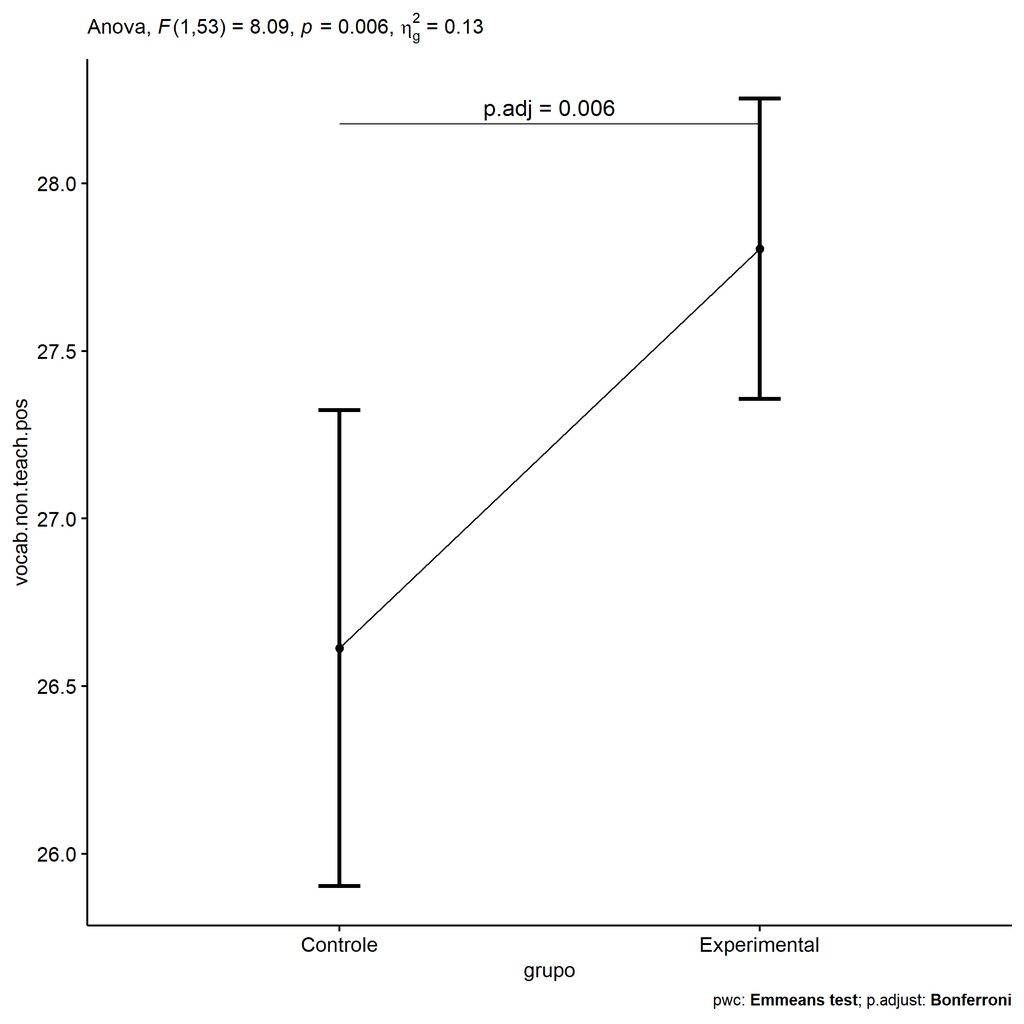

```r
if (!is.null(nrow(plots[["grupo"]]$data)))
  plots[["grupo"]] + ggplot2::scale_color_manual(values = color[["grupo"]])
```

```r
plots <- oneWayAncovaBoxPlots(
  wdat, "vocab.non.teach.pos", "grupo", aov, pwc, covar = "vocab.non.teach.pre",
  theme = "classic", color = color[["grupo"]],
  subtitle = which(aov$Effect == "grupo"))
```

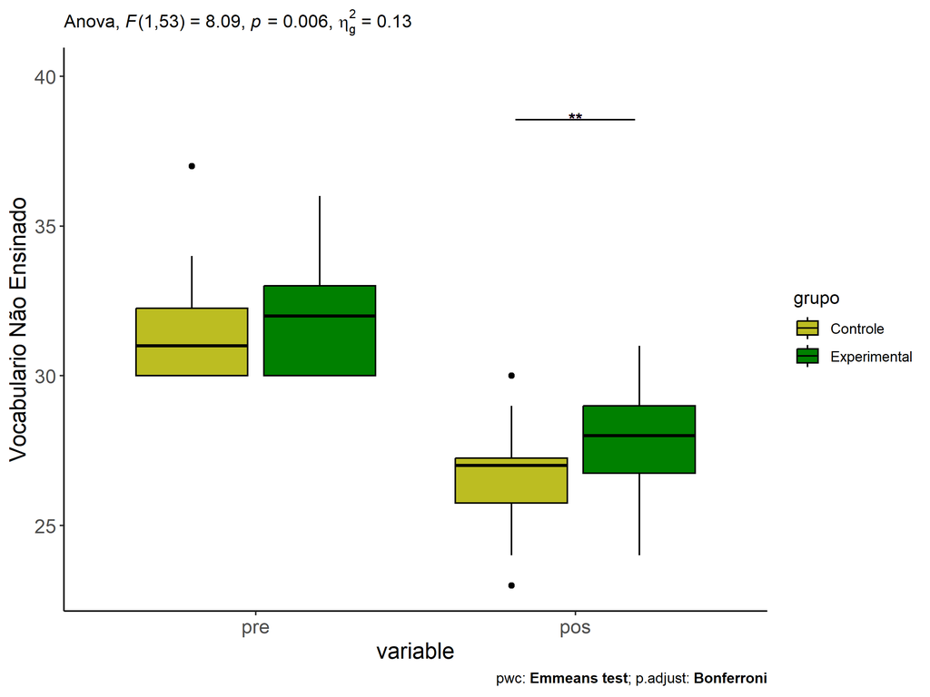

```r
if (length(unique(wdat[["grupo"]])) > 1)
  plots[["grupo"]] + ggplot2::ylab("Vocabulario Não Ensinado") + ggplot2::scale_x_discrete(labels=c('pre', 'pos'))
```

```r
if (length(unique(wdat.long[["grupo"]])) > 1)
  plots <- oneWayAncovaBoxPlots(
    wdat.long, "vocab.non.teach", "grupo", aov, pwc.long, pre.post = "time",
    theme = "classic", color = color$prepost)
```

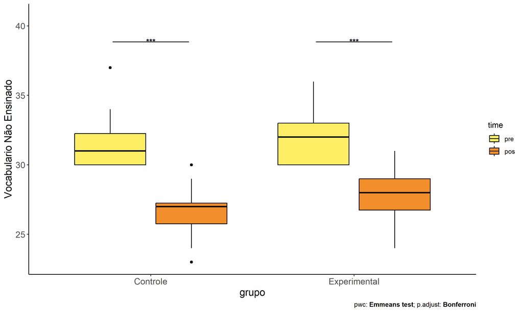

```r
if (length(unique(wdat.long[["grupo"]])) > 1)
  plots[["grupo"]] + ggplot2::ylab("Vocabulario Não Ensinado")
```

### Checking linearity assumption

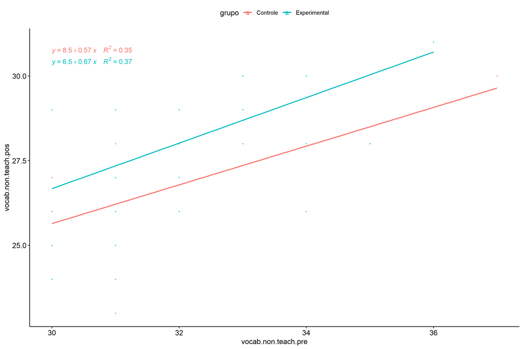

```r
ggscatter(wdat, x = "vocab.non.teach.pre", y = "vocab.non.teach.pos", size = 0.5,
          color = "grupo", add = "reg.line")+
  stat_regline_equation(
    aes(label =  paste(..eq.label.., ..rr.label.., sep = "~~~~"), color = grupo)
  )
```

### Checking normality and homogeneity

```r
res <- augment(lm(vocab.non.teach.pos ~ vocab.non.teach.pre + grupo, data = wdat))
```

```r
shapiro_test(res$.resid)
```

```
## # A tibble: 1 × 3
##   variable   statistic p.value
##   <chr>          <dbl>   <dbl>
## 1 res$.resid     0.963  0.0810
```

```r
levene_test(res, .resid ~ grupo)
```

```
## # A tibble: 1 × 4
##     df1   df2 statistic     p
##   <int> <int>     <dbl> <dbl>
## 1     1    54   0.00173 0.967
```

# ANCOVA and Pairwise for two factors **grupo:Sexo**

## Without remove non-normal data

```r
pdat = remove_group_data(dat[!is.na(dat[["grupo"]]) & !is.na(dat[["Sexo"]]),], "vocab.non.teach.pos", c("grupo","Sexo"))

pdat.long <- rbind(pdat[,c("id","grupo","Sexo")], pdat[,c("id","grupo","Sexo")])
pdat.long[["time"]] <- c(rep("pre", nrow(pdat)), rep("pos", nrow(pdat)))
pdat.long[["time"]] <- factor(pdat.long[["time"]], c("pre","pos"))
pdat.long[["vocab.non.teach"]] <- c(pdat[["vocab.non.teach.pre"]], pdat[["vocab.non.teach.pos"]])

aov = anova_test(pdat, vocab.non.teach.pos ~ vocab.non.teach.pre + grupo*Sexo)
laov[["grupo:Sexo"]] <- get_anova_table(aov)
```

```r
pwcs <- list()
pwcs[["Sexo"]] <- emmeans_test(
  group_by(pdat, grupo), vocab.non.teach.pos ~ Sexo,
  covariate = vocab.non.teach.pre, p.adjust.method = "bonferroni")
pwcs[["grupo"]] <- emmeans_test(
  group_by(pdat, Sexo), vocab.non.teach.pos ~ grupo,
  covariate = vocab.non.teach.pre, p.adjust.method = "bonferroni")

pwc <- plyr::rbind.fill(pwcs[["grupo"]], pwcs[["Sexo"]])
pwc <- pwc[,c("grupo","Sexo", colnames(pwc)[!colnames(pwc) %in% c("grupo","Sexo")])]
```

```r
pwc.long <- emmeans_test(dplyr::group_by_at(pdat.long, c("grupo","Sexo")),
                         vocab.non.teach ~ time,
                         p.adjust.method = "bonferroni")
lpwc[["grupo:Sexo"]] <- plyr::rbind.fill(pwc, pwc.long)
```

```r
ds <- get.descriptives(pdat, "vocab.non.teach.pos", c("grupo","Sexo"), covar = "vocab.non.teach.pre")
ds <- merge(ds[ds$variable != "vocab.non.teach.pre",],
            ds[ds$variable == "vocab.non.teach.pre", !colnames(ds) %in% c("variable")],
            by = c("grupo","Sexo"), all.x = T, suffixes = c("", ".vocab.non.teach.pre"))
ds <- merge(get_emmeans(pwcs[["grupo"]]), ds, by = c("grupo","Sexo"), suffixes = c(".emms", ""))
ds <- ds[,c("grupo","Sexo","n","mean.vocab.non.teach.pre","se.vocab.non.teach.pre","mean","se","emmean","se.emms")]

colnames(ds) <- c("grupo","Sexo", "N", paste0(c("M","SE")," (pre)"),
                  paste0(c("M","SE"), " (unadj)"), paste0(c("M", "SE"), " (adj)"))

lemms[["grupo:Sexo"]] <- ds
```

## Computing ANCOVA and PairWise After removing non-normal data (OK)

```r
wdat = pdat

res = residuals(lm(vocab.non.teach.pos ~ vocab.non.teach.pre + grupo*Sexo, data = wdat))
non.normal = getNonNormal(res, wdat$id, plimit = 0.05)

wdat = wdat[!wdat$id %in% non.normal,]

wdat.long <- rbind(wdat[,c("id","grupo","Sexo")], wdat[,c("id","grupo","Sexo")])
wdat.long[["time"]] <- c(rep("pre", nrow(wdat)), rep("pos", nrow(wdat)))
wdat.long[["time"]] <- factor(wdat.long[["time"]], c("pre","pos"))
wdat.long[["vocab.non.teach"]] <- c(wdat[["vocab.non.teach.pre"]], wdat[["vocab.non.teach.pos"]])


ldat[["grupo:Sexo"]] = wdat

(non.normal)
```

```
##   [1] "P1003" "P2207" "P983"  "P2232" "P3654" "P1966" "P996"  "P976"  "P1794" "P916"  "P1012" "P1865"
##  [13] "P2069" "P3280" "P2066" "P526"  "P3228" "P1116" "P2322" "P3574" "P2306" "P1060" "P999"  "P2113"
##  [25] "P932"  "P633"  "P2432" "P2447" "P1100" "P3723" "P3720" "P3157" "P1851" "P1085" "P1985" "P3258"
##  [37] "P2146" "P2079" "P596"  "P3225" "P3222" "P2428" "P2459" "P2150" "P3284" "P3610" "P2123" "P3719"
##  [49] "P3138" "P3646" "P1138" "P2387" "P1876" "P2379" "P3151" "P986"  "P2191" "P2008" "P2299" "P2065"
##  [61] "P3676" "P3242" "P1001" "P1888" "P2412" "P2300" "P2475" "P2367" "P1853" "P2423" "P2360" "P1617"
##  [73] "P3657" "P2869" "P588"  "P1650" "P2361" "P2292" "P3245" "P2298" "P1679" "P3264" "P1761" "P3192"
##  [85] "P3144" "P2323" "P2139" "P2225" "P3589" "P1153" "P3171" "P3283" "P1648" "P2431" "P1749" "P828"
##  [97] "P3202" "P2871" "P1825" "P2064" "P3129" "P2370" "P2118" "P605"  "P2441" "P1908" "P1846" "P3301"
## [109] "P1879" "P2984" "P2343" "P2845" "P2476" "P2295" "P1133" "P1900" "P3708" "P1665" "P2196" "P2372"
## [121] "P3147" "P3226" "P1913" "P1061" "P3688" "P2354" "P2452" "P2181" "P1800" "P3643" "P2308" "P2910"
## [133] "P928"  "P552"  "P1652" "P2381" "P2457" "P2480" "P1674" "P2467" "P2131" "P2948" "P846"  "P3079"
## [145] "P3639" "P2436" "P600"  "P2393" "P3587" "P832"  "P1848" "P2188" "P3148" "P2477" "P2200" "P3576"
## [157] "P1689" "P980"  "P2990" "P2357" "P1833" "P3491" "P3645" "P3693" "P2296" "P2362" "P2394" "P3150"
## [169] "P2141" "P2170" "P2338"
```

```r
aov = anova_test(wdat, vocab.non.teach.pos ~ vocab.non.teach.pre + grupo*Sexo)
laov[["grupo:Sexo"]] <- merge(get_anova_table(aov), laov[["grupo:Sexo"]], by="Effect", suffixes = c("","'"))

(df = get_anova_table(aov))
```

```
## ANOVA Table (type II tests)
##
##                Effect DFn DFd      F        p p<.05   ges
## 1 vocab.non.teach.pre   1  50 24.924 7.63e-06     * 0.333
## 2               grupo   1  50  5.047 2.90e-02     * 0.092
## 3                Sexo   1  50  0.813 3.71e-01       0.016
## 4          grupo:Sexo   1  50  0.076 7.83e-01       0.002
```

| Effect | DFn | DFd | F | p | p<.05 | ges |
| --- | --- | --- | --- | --- | --- | --- |
| vocab.non.teach.pre | 1 | 50 | 24.924 | 0.000 | * | 0.333 |
| grupo | 1 | 50 | 5.047 | 0.029 | * | 0.092 |
| Sexo | 1 | 50 | 0.813 | 0.371 |  | 0.016 |
| grupo:Sexo | 1 | 50 | 0.076 | 0.783 |  | 0.002 |

```r
pwcs <- list()
pwcs[["Sexo"]] <- emmeans_test(
  group_by(wdat, grupo), vocab.non.teach.pos ~ Sexo,
  covariate = vocab.non.teach.pre, p.adjust.method = "bonferroni")
pwcs[["grupo"]] <- emmeans_test(
  group_by(wdat, Sexo), vocab.non.teach.pos ~ grupo,
  covariate = vocab.non.teach.pre, p.adjust.method = "bonferroni")

pwc <- plyr::rbind.fill(pwcs[["grupo"]], pwcs[["Sexo"]])
pwc <- pwc[,c("grupo","Sexo", colnames(pwc)[!colnames(pwc) %in% c("grupo","Sexo")])]
```

| grupo | Sexo | term | .y. | group1 | group2 | df | statistic | p | p.adj | p.adj.signif |
| --- | --- | --- | --- | --- | --- | --- | --- | --- | --- | --- |
|  | F | vocab.non.teach.pre*grupo | vocab.non.teach.pos | Controle | Experimental | 50 | -1.892 | 0.064 | 0.064 | ns |
|  | M | vocab.non.teach.pre*grupo | vocab.non.teach.pos | Controle | Experimental | 50 | -1.253 | 0.216 | 0.216 | ns |
| Controle |  | vocab.non.teach.pre*Sexo | vocab.non.teach.pos | F | M | 50 | 0.283 | 0.778 | 0.778 | ns |
| Experimental |  | vocab.non.teach.pre*Sexo | vocab.non.teach.pos | F | M | 50 | 0.911 | 0.367 | 0.367 | ns |

```r
pwc.long <- emmeans_test(dplyr::group_by_at(wdat.long, c("grupo","Sexo")),
                         vocab.non.teach ~ time,
                         p.adjust.method = "bonferroni")
lpwc[["grupo:Sexo"]] <- merge(plyr::rbind.fill(pwc, pwc.long), lpwc[["grupo:Sexo"]], by=c("grupo","Sexo","term",".y.","group1","group2"), suffixes = c("","'"))
```

| grupo | Sexo | term | .y. | group1 | group2 | df | statistic | p | p.adj | p.adj.signif |
| --- | --- | --- | --- | --- | --- | --- | --- | --- | --- | --- |
| Controle | F | time | vocab.non.teach | pre | pos | 102 | 6.473 | 0 | 0 | **** |
| Controle | M | time | vocab.non.teach | pre | pos | 102 | 5.210 | 0 | 0 | **** |
| Experimental | F | time | vocab.non.teach | pre | pos | 102 | 7.566 | 0 | 0 | **** |
| Experimental | M | time | vocab.non.teach | pre | pos | 102 | 6.991 | 0 | 0 | **** |

```r
ds <- get.descriptives(wdat, "vocab.non.teach.pos", c("grupo","Sexo"), covar = "vocab.non.teach.pre")
ds <- merge(ds[ds$variable != "vocab.non.teach.pre",],
            ds[ds$variable == "vocab.non.teach.pre", !colnames(ds) %in% c("variable")],
            by = c("grupo","Sexo"), all.x = T, suffixes = c("", ".vocab.non.teach.pre"))
ds <- merge(get_emmeans(pwcs[["grupo"]]), ds, by = c("grupo","Sexo"), suffixes = c(".emms", ""))
ds <- ds[,c("grupo","Sexo","n","mean.vocab.non.teach.pre","se.vocab.non.teach.pre","mean","se","emmean","se.emms")]

colnames(ds) <- c("grupo","Sexo", "N", paste0(c("M","SE")," (pre)"),
                  paste0(c("M","SE"), " (unadj)"), paste0(c("M", "SE"), " (adj)"))

lemms[["grupo:Sexo"]] <- merge(ds, lemms[["grupo:Sexo"]], by=c("grupo","Sexo"), suffixes = c("","'"))
```

| grupo | Sexo | N | M (pre) | SE (pre) | M (unadj) | SE (unadj) | M (adj) | SE (adj) |
| --- | --- | --- | --- | --- | --- | --- | --- | --- |
| Controle | F | 10 | 31.900 | 0.706 | 27.000 | 0.537 | 26.869 | 0.460 |
| Controle | M | 7 | 30.857 | 0.404 | 26.143 | 0.829 | 26.664 | 0.558 |
| Experimental | F | 21 | 32.190 | 0.363 | 28.238 | 0.371 | 27.926 | 0.323 |
| Experimental | M | 17 | 31.294 | 0.318 | 27.235 | 0.407 | 27.483 | 0.355 |

### Plots for ancova

```r
plots <- twoWayAncovaPlots(
  wdat, "vocab.non.teach.pos", c("grupo","Sexo"), aov, pwcs, addParam = c("mean_se"),
  font.label.size=10, step.increase=0.05, p.label="p.adj",
  subtitle = which(aov$Effect == "grupo:Sexo"))
```

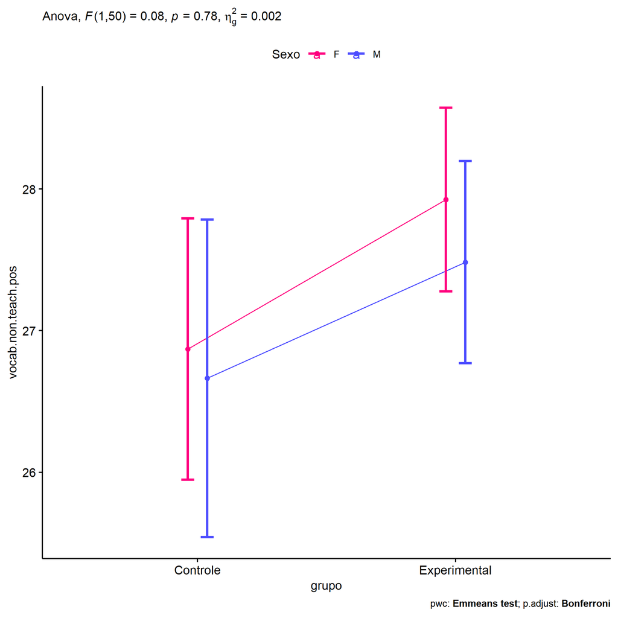

```r
if (!is.null(plots[["grupo"]]))
  plots[["grupo"]] + ggplot2::scale_color_manual(values = color[["Sexo"]])
```

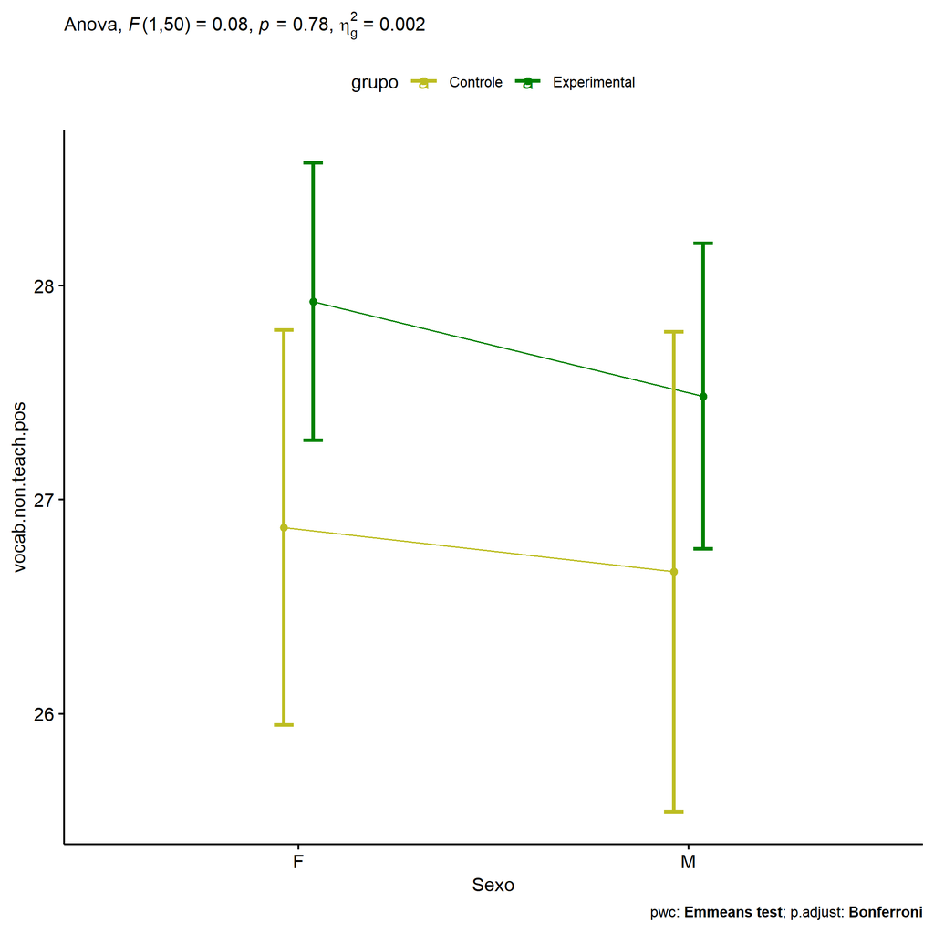

```r
if (!is.null(plots[["Sexo"]]))
  plots[["Sexo"]] + ggplot2::scale_color_manual(values = color[["grupo"]])
```

```r
plots <- twoWayAncovaBoxPlots(
  wdat, "vocab.non.teach.pos", c("grupo","Sexo"), aov, pwcs, covar = "vocab.non.teach.pre",
  theme = "classic", color = color[["grupo:Sexo"]],
  subtitle = which(aov$Effect == "grupo:Sexo"))
```

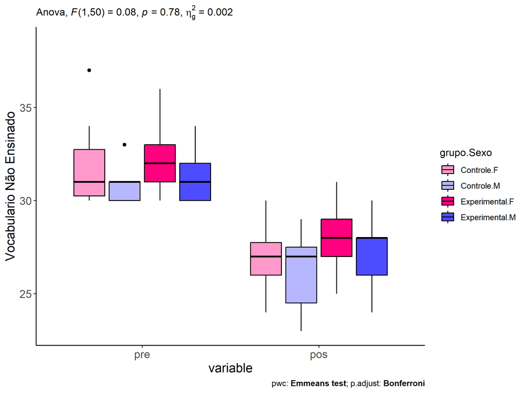

```r
plots[["grupo:Sexo"]] + ggplot2::ylab("Vocabulario Não Ensinado") + ggplot2::scale_x_discrete(labels=c('pre', 'pos'))
```

```r
plots <- twoWayAncovaBoxPlots(
  wdat.long, "vocab.non.teach", c("grupo","Sexo"), aov, pwc.long, pre.post = "time",
  theme = "classic", color = color$prepost)
```

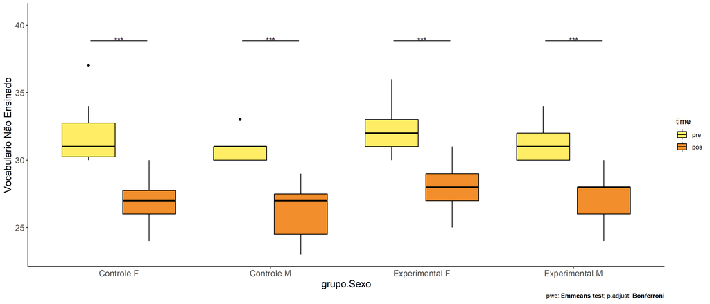

```r
plots[["grupo:Sexo"]] + ggplot2::ylab("Vocabulario Não Ensinado")
```

### Checking linearity assumption

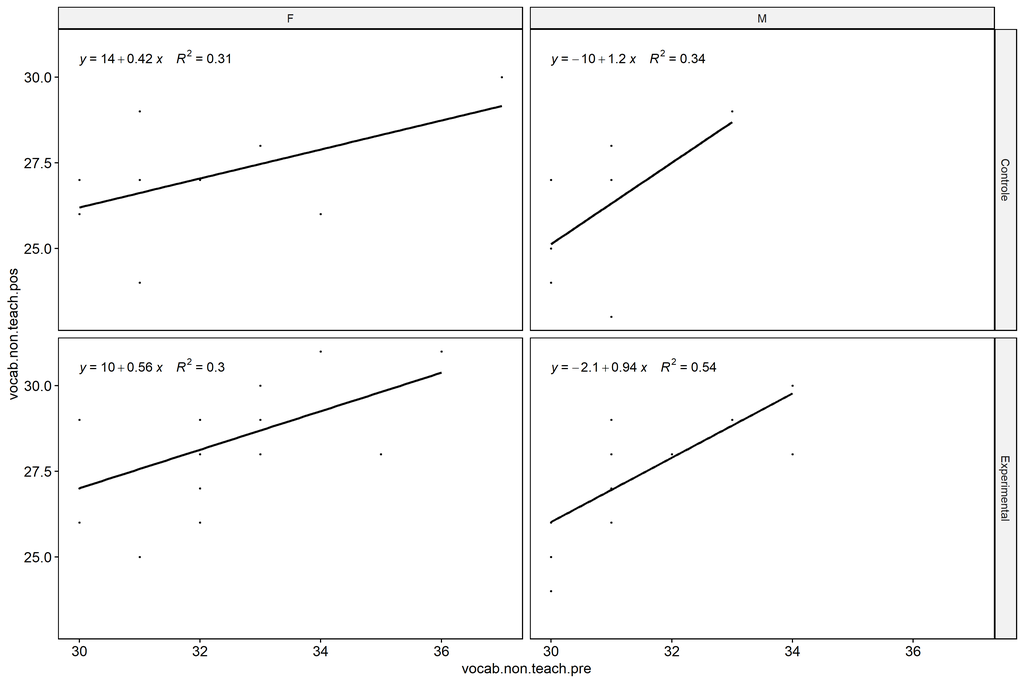

```r
ggscatter(wdat, x = "vocab.non.teach.pre", y = "vocab.non.teach.pos", size = 0.5,
          facet.by = c("grupo","Sexo"), add = "reg.line")+
  stat_regline_equation(
    aes(label =  paste(..eq.label.., ..rr.label.., sep = "~~~~"))
  )
```

### Checking normality and homogeneity

```r
res <- augment(lm(vocab.non.teach.pos ~ vocab.non.teach.pre + grupo*Sexo, data = wdat))
```

```r
shapiro_test(res$.resid)
```

```
## # A tibble: 1 × 3
##   variable   statistic p.value
##   <chr>          <dbl>   <dbl>
## 1 res$.resid     0.972   0.223
```

```r
levene_test(res, .resid ~ grupo*Sexo)
```

```
## # A tibble: 1 × 4
##     df1   df2 statistic     p
##   <int> <int>     <dbl> <dbl>
## 1     3    51     0.565 0.640
```

# ANCOVA and Pairwise for two factors **grupo:Zona**

## Without remove non-normal data

```r
pdat = remove_group_data(dat[!is.na(dat[["grupo"]]) & !is.na(dat[["Zona"]]),], "vocab.non.teach.pos", c("grupo","Zona"))

pdat.long <- rbind(pdat[,c("id","grupo","Zona")], pdat[,c("id","grupo","Zona")])
pdat.long[["time"]] <- c(rep("pre", nrow(pdat)), rep("pos", nrow(pdat)))
pdat.long[["time"]] <- factor(pdat.long[["time"]], c("pre","pos"))
pdat.long[["vocab.non.teach"]] <- c(pdat[["vocab.non.teach.pre"]], pdat[["vocab.non.teach.pos"]])

aov = anova_test(pdat, vocab.non.teach.pos ~ vocab.non.teach.pre + grupo*Zona)
laov[["grupo:Zona"]] <- get_anova_table(aov)
```

```r
pwcs <- list()
pwcs[["Zona"]] <- emmeans_test(
  group_by(pdat, grupo), vocab.non.teach.pos ~ Zona,
  covariate = vocab.non.teach.pre, p.adjust.method = "bonferroni")
pwcs[["grupo"]] <- emmeans_test(
  group_by(pdat, Zona), vocab.non.teach.pos ~ grupo,
  covariate = vocab.non.teach.pre, p.adjust.method = "bonferroni")

pwc <- plyr::rbind.fill(pwcs[["grupo"]], pwcs[["Zona"]])
pwc <- pwc[,c("grupo","Zona", colnames(pwc)[!colnames(pwc) %in% c("grupo","Zona")])]
```

```r
pwc.long <- emmeans_test(dplyr::group_by_at(pdat.long, c("grupo","Zona")),
                         vocab.non.teach ~ time,
                         p.adjust.method = "bonferroni")
lpwc[["grupo:Zona"]] <- plyr::rbind.fill(pwc, pwc.long)
```

```r
ds <- get.descriptives(pdat, "vocab.non.teach.pos", c("grupo","Zona"), covar = "vocab.non.teach.pre")
ds <- merge(ds[ds$variable != "vocab.non.teach.pre",],
            ds[ds$variable == "vocab.non.teach.pre", !colnames(ds) %in% c("variable")],
            by = c("grupo","Zona"), all.x = T, suffixes = c("", ".vocab.non.teach.pre"))
ds <- merge(get_emmeans(pwcs[["grupo"]]), ds, by = c("grupo","Zona"), suffixes = c(".emms", ""))
ds <- ds[,c("grupo","Zona","n","mean.vocab.non.teach.pre","se.vocab.non.teach.pre","mean","se","emmean","se.emms")]

colnames(ds) <- c("grupo","Zona", "N", paste0(c("M","SE")," (pre)"),
                  paste0(c("M","SE"), " (unadj)"), paste0(c("M", "SE"), " (adj)"))

lemms[["grupo:Zona"]] <- ds
```

## Computing ANCOVA and PairWise After removing non-normal data (OK)

```r
wdat = pdat

res = residuals(lm(vocab.non.teach.pos ~ vocab.non.teach.pre + grupo*Zona, data = wdat))
non.normal = getNonNormal(res, wdat$id, plimit = 0.05)

wdat = wdat[!wdat$id %in% non.normal,]

wdat.long <- rbind(wdat[,c("id","grupo","Zona")], wdat[,c("id","grupo","Zona")])
wdat.long[["time"]] <- c(rep("pre", nrow(wdat)), rep("pos", nrow(wdat)))
wdat.long[["time"]] <- factor(wdat.long[["time"]], c("pre","pos"))
wdat.long[["vocab.non.teach"]] <- c(wdat[["vocab.non.teach.pre"]], wdat[["vocab.non.teach.pos"]])


ldat[["grupo:Zona"]] = wdat

(non.normal)
```

```
## [1] "P983"  "P2207" "P3654" "P1966" "P1794" "P976"  "P3228" "P916"  "P2069"
```

```r
aov = anova_test(wdat, vocab.non.teach.pos ~ vocab.non.teach.pre + grupo*Zona)
laov[["grupo:Zona"]] <- merge(get_anova_table(aov), laov[["grupo:Zona"]], by="Effect", suffixes = c("","'"))

(df = get_anova_table(aov))
```

```
## ANOVA Table (type II tests)
##
##                Effect DFn DFd     F     p p<.05      ges
## 1 vocab.non.teach.pre   1 128 5.758 0.018     * 0.043000
## 2               grupo   1 128 0.121 0.728       0.000945
## 3                Zona   1 128 0.753 0.387       0.006000
## 4          grupo:Zona   1 128 0.155 0.695       0.001000
```

| Effect | DFn | DFd | F | p | p<.05 | ges |
| --- | --- | --- | --- | --- | --- | --- |
| vocab.non.teach.pre | 1 | 128 | 5.758 | 0.018 | * | 0.043 |
| grupo | 1 | 128 | 0.121 | 0.728 |  | 0.001 |
| Zona | 1 | 128 | 0.753 | 0.387 |  | 0.006 |
| grupo:Zona | 1 | 128 | 0.155 | 0.695 |  | 0.001 |

```r
pwcs <- list()
pwcs[["Zona"]] <- emmeans_test(
  group_by(wdat, grupo), vocab.non.teach.pos ~ Zona,
  covariate = vocab.non.teach.pre, p.adjust.method = "bonferroni")
pwcs[["grupo"]] <- emmeans_test(
  group_by(wdat, Zona), vocab.non.teach.pos ~ grupo,
  covariate = vocab.non.teach.pre, p.adjust.method = "bonferroni")

pwc <- plyr::rbind.fill(pwcs[["grupo"]], pwcs[["Zona"]])
pwc <- pwc[,c("grupo","Zona", colnames(pwc)[!colnames(pwc) %in% c("grupo","Zona")])]
```

| grupo | Zona | term | .y. | group1 | group2 | df | statistic | p | p.adj | p.adj.signif |
| --- | --- | --- | --- | --- | --- | --- | --- | --- | --- | --- |
|  | Rural | vocab.non.teach.pre*grupo | vocab.non.teach.pos | Controle | Experimental | 128 | 0.524 | 0.601 | 0.601 | ns |
|  | Urbana | vocab.non.teach.pre*grupo | vocab.non.teach.pos | Controle | Experimental | 128 | -0.038 | 0.970 | 0.970 | ns |
| Controle |  | vocab.non.teach.pre*Zona | vocab.non.teach.pos | Rural | Urbana | 128 | -0.229 | 0.819 | 0.819 | ns |
| Experimental |  | vocab.non.teach.pre*Zona | vocab.non.teach.pos | Rural | Urbana | 128 | -0.926 | 0.356 | 0.356 | ns |

```r
pwc.long <- emmeans_test(dplyr::group_by_at(wdat.long, c("grupo","Zona")),
                         vocab.non.teach ~ time,
                         p.adjust.method = "bonferroni")
lpwc[["grupo:Zona"]] <- merge(plyr::rbind.fill(pwc, pwc.long), lpwc[["grupo:Zona"]], by=c("grupo","Zona","term",".y.","group1","group2"), suffixes = c("","'"))
```

| grupo | Zona | term | .y. | group1 | group2 | df | statistic | p | p.adj | p.adj.signif |
| --- | --- | --- | --- | --- | --- | --- | --- | --- | --- | --- |
| Controle | Rural | time | vocab.non.teach | pre | pos | 258 | 1.183 | 0.238 | 0.238 | ns |
| Controle | Urbana | time | vocab.non.teach | pre | pos | 258 | 0.483 | 0.630 | 0.630 | ns |
| Experimental | Rural | time | vocab.non.teach | pre | pos | 258 | 2.327 | 0.021 | 0.021 | * |
| Experimental | Urbana | time | vocab.non.teach | pre | pos | 258 | 0.906 | 0.366 | 0.366 | ns |

```r
ds <- get.descriptives(wdat, "vocab.non.teach.pos", c("grupo","Zona"), covar = "vocab.non.teach.pre")
ds <- merge(ds[ds$variable != "vocab.non.teach.pre",],
            ds[ds$variable == "vocab.non.teach.pre", !colnames(ds) %in% c("variable")],
            by = c("grupo","Zona"), all.x = T, suffixes = c("", ".vocab.non.teach.pre"))
ds <- merge(get_emmeans(pwcs[["grupo"]]), ds, by = c("grupo","Zona"), suffixes = c(".emms", ""))
ds <- ds[,c("grupo","Zona","n","mean.vocab.non.teach.pre","se.vocab.non.teach.pre","mean","se","emmean","se.emms")]

colnames(ds) <- c("grupo","Zona", "N", paste0(c("M","SE")," (pre)"),
                  paste0(c("M","SE"), " (unadj)"), paste0(c("M", "SE"), " (adj)"))

lemms[["grupo:Zona"]] <- merge(ds, lemms[["grupo:Zona"]], by=c("grupo","Zona"), suffixes = c("","'"))
```

| grupo | Zona | N | M (pre) | SE (pre) | M (unadj) | SE (unadj) | M (adj) | SE (adj) |
| --- | --- | --- | --- | --- | --- | --- | --- | --- |
| Controle | Rural | 26 | 31.885 | 0.431 | 31.115 | 0.676 | 31.087 | 0.540 |
| Controle | Urbana | 25 | 31.480 | 0.327 | 31.160 | 0.464 | 31.264 | 0.552 |
| Experimental | Rural | 42 | 31.976 | 0.232 | 30.786 | 0.415 | 30.727 | 0.425 |
| Experimental | Urbana | 40 | 31.750 | 0.286 | 31.275 | 0.431 | 31.290 | 0.435 |

### Plots for ancova

```r
plots <- twoWayAncovaPlots(
  wdat, "vocab.non.teach.pos", c("grupo","Zona"), aov, pwcs, addParam = c("mean_se"),
  font.label.size=10, step.increase=0.05, p.label="p.adj",
  subtitle = which(aov$Effect == "grupo:Zona"))
```

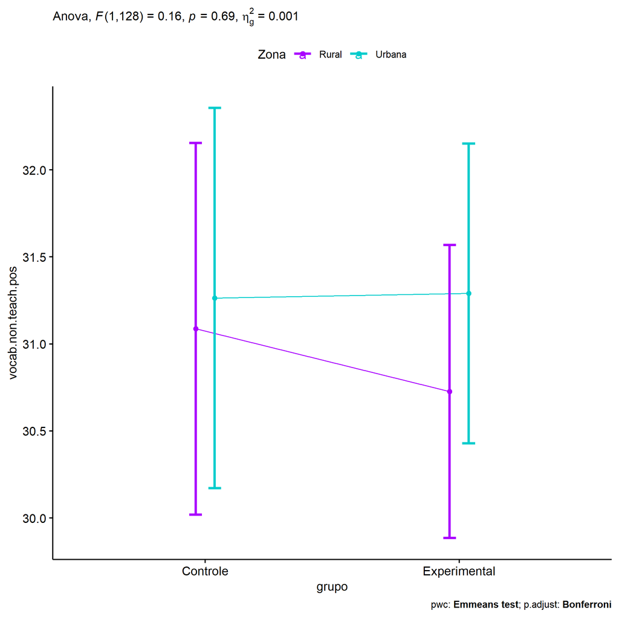

```r
if (!is.null(plots[["grupo"]]))
  plots[["grupo"]] + ggplot2::scale_color_manual(values = color[["Zona"]])
```

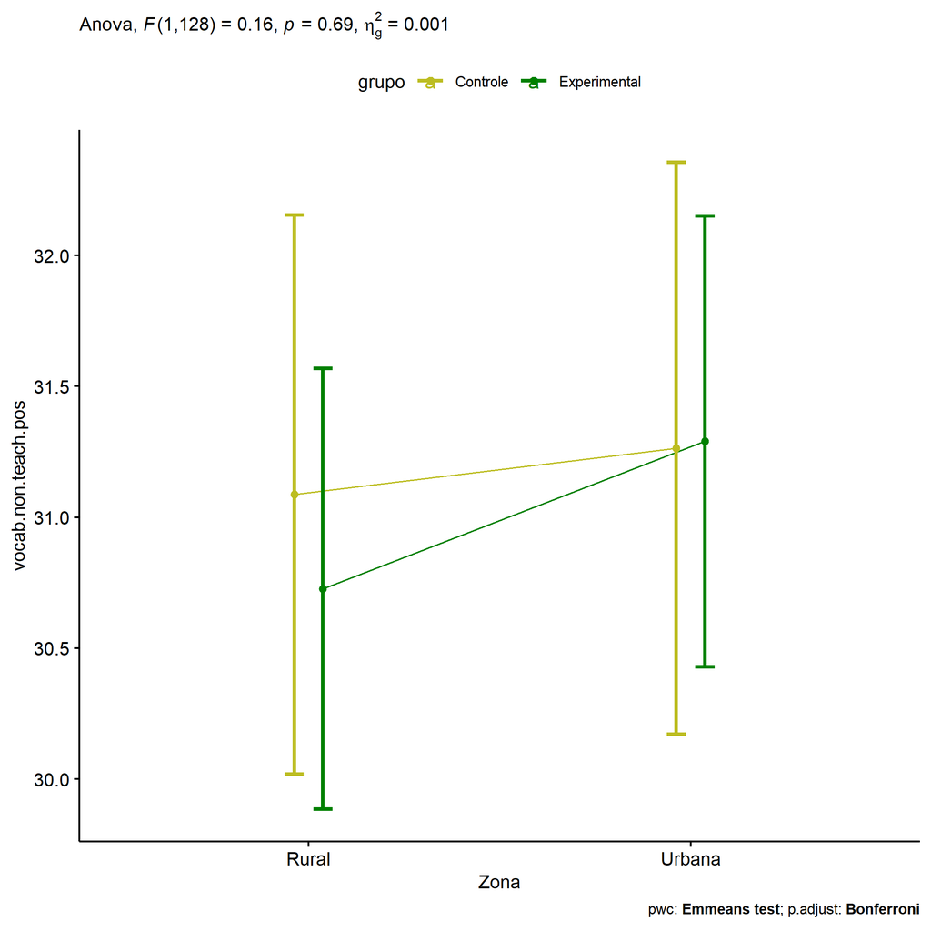

```r
if (!is.null(plots[["Zona"]]))
  plots[["Zona"]] + ggplot2::scale_color_manual(values = color[["grupo"]])
```

```r
plots <- twoWayAncovaBoxPlots(
  wdat, "vocab.non.teach.pos", c("grupo","Zona"), aov, pwcs, covar = "vocab.non.teach.pre",
  theme = "classic", color = color[["grupo:Zona"]],
  subtitle = which(aov$Effect == "grupo:Zona"))
```

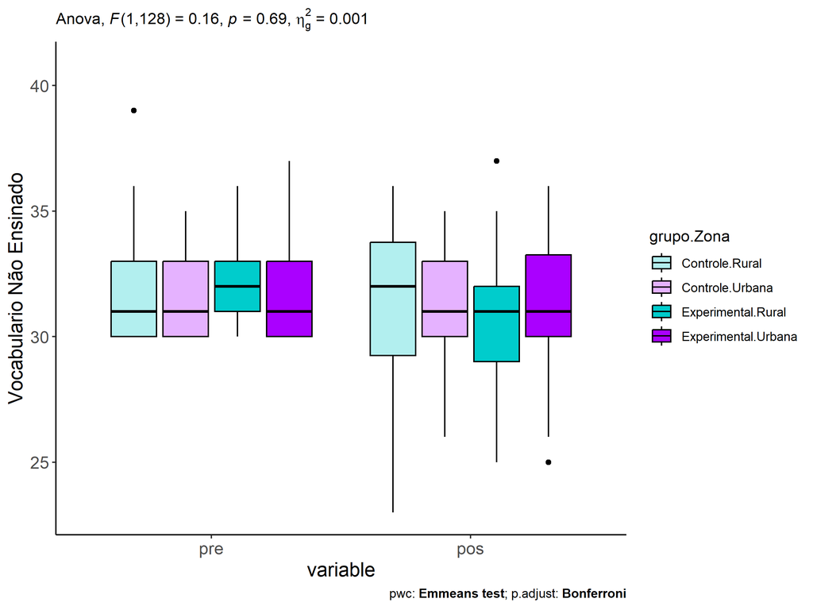

```r
plots[["grupo:Zona"]] + ggplot2::ylab("Vocabulario Não Ensinado") + ggplot2::scale_x_discrete(labels=c('pre', 'pos'))
```

```r
plots <- twoWayAncovaBoxPlots(
  wdat.long, "vocab.non.teach", c("grupo","Zona"), aov, pwc.long, pre.post = "time",
  theme = "classic", color = color$prepost)
```

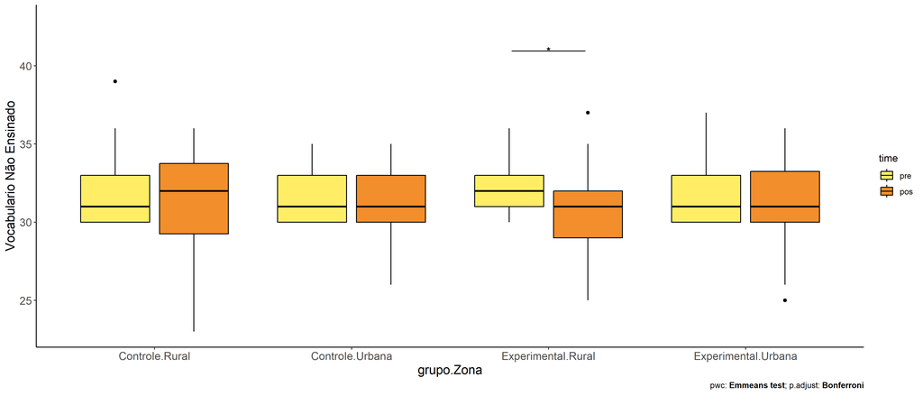

```r
plots[["grupo:Zona"]] + ggplot2::ylab("Vocabulario Não Ensinado")
```

### Checking linearity assumption

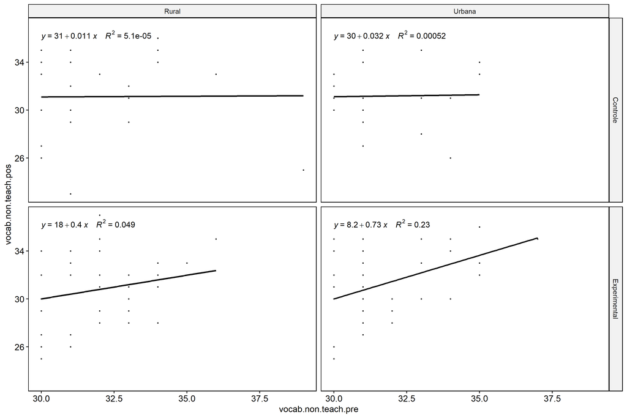

```r
ggscatter(wdat, x = "vocab.non.teach.pre", y = "vocab.non.teach.pos", size = 0.5,
          facet.by = c("grupo","Zona"), add = "reg.line")+
  stat_regline_equation(
    aes(label =  paste(..eq.label.., ..rr.label.., sep = "~~~~"))
  )
```

### Checking normality and homogeneity

```r
res <- augment(lm(vocab.non.teach.pos ~ vocab.non.teach.pre + grupo*Zona, data = wdat))
```

```r
shapiro_test(res$.resid)
```

```
## # A tibble: 1 × 3
##   variable   statistic p.value
##   <chr>          <dbl>   <dbl>
## 1 res$.resid     0.982  0.0734
```

```r
levene_test(res, .resid ~ grupo*Zona)
```

```
## # A tibble: 1 × 4
##     df1   df2 statistic     p
##   <int> <int>     <dbl> <dbl>
## 1     3   129      1.35 0.260
```

# ANCOVA and Pairwise for two factors **grupo:Cor.Raca**

## Without remove non-normal data

```r
pdat = remove_group_data(dat[!is.na(dat[["grupo"]]) & !is.na(dat[["Cor.Raca"]]),], "vocab.non.teach.pos", c("grupo","Cor.Raca"))
pdat.long <- rbind(pdat[,c("id","grupo","Cor.Raca")], pdat[,c("id","grupo","Cor.Raca")])
pdat.long[["time"]] <- c(rep("pre", nrow(pdat)), rep("pos", nrow(pdat)))
pdat.long[["time"]] <- factor(pdat.long[["time"]], c("pre","pos"))
pdat.long[["vocab.non.teach"]] <- c(pdat[["vocab.non.teach.pre"]], pdat[["vocab.non.teach.pos"]])

aov = anova_test(pdat, vocab.non.teach.pos ~ vocab.non.teach.pre + grupo*Cor.Raca)
laov[["grupo:Cor.Raca"]] <- get_anova_table(aov)
```

```r
pwcs <- list()
pwcs[["Cor.Raca"]] <- emmeans_test(
  group_by(pdat, grupo), vocab.non.teach.pos ~ Cor.Raca,
  covariate = vocab.non.teach.pre, p.adjust.method = "bonferroni")
pwcs[["grupo"]] <- emmeans_test(
  group_by(pdat, Cor.Raca), vocab.non.teach.pos ~ grupo,
  covariate = vocab.non.teach.pre, p.adjust.method = "bonferroni")

pwc <- plyr::rbind.fill(pwcs[["grupo"]], pwcs[["Cor.Raca"]])
pwc <- pwc[,c("grupo","Cor.Raca", colnames(pwc)[!colnames(pwc) %in% c("grupo","Cor.Raca")])]
```

```r
pwc.long <- emmeans_test(dplyr::group_by_at(pdat.long, c("grupo","Cor.Raca")),
                         vocab.non.teach ~ time,
                         p.adjust.method = "bonferroni")
lpwc[["grupo:Cor.Raca"]] <- plyr::rbind.fill(pwc, pwc.long)
```

```r
ds <- get.descriptives(pdat, "vocab.non.teach.pos", c("grupo","Cor.Raca"), covar = "vocab.non.teach.pre")
ds <- merge(ds[ds$variable != "vocab.non.teach.pre",],
            ds[ds$variable == "vocab.non.teach.pre", !colnames(ds) %in% c("variable")],
            by = c("grupo","Cor.Raca"), all.x = T, suffixes = c("", ".vocab.non.teach.pre"))
ds <- merge(get_emmeans(pwcs[["grupo"]]), ds, by = c("grupo","Cor.Raca"), suffixes = c(".emms", ""))
ds <- ds[,c("grupo","Cor.Raca","n","mean.vocab.non.teach.pre","se.vocab.non.teach.pre","mean","se","emmean","se.emms")]

colnames(ds) <- c("grupo","Cor.Raca", "N", paste0(c("M","SE")," (pre)"),
                  paste0(c("M","SE"), " (unadj)"), paste0(c("M", "SE"), " (adj)"))

lemms[["grupo:Cor.Raca"]] <- ds
```